# zadanie6

Katarzyna Janiak

7 maja 2018

# Szczecin

Tutatj si?? urodzi??am i wychowa??am. Miasto po??o??one jest w wojew??dztwie zachodniopomorskim, ale nie ma bezpo??redniego dost??pu do morza, jak wiele os??b uwa??a. Mamy za to inne atrakcje:

1. *Wa??y Chrobrego*
2. *Jasne B??onia*
3. *Teatr Wsp????czesny*

# Wa??y Chrobrego*

Jest to kompleks ogromnych taras??w po??o??onych na skarpie wzd??u?? Odry.Z nich mo??na zobaczy?? drug?? cz?????? miasta tzw. *prawobrze??e*. W okresie letnim s?? tam t??umy. Nic dziwnego, sama lubi?? tam spacerowa??. Jest tam te?? sporo restauracji i kawiarni. Polecam *Palladin*- maj?? pyszn?? pizz??.

## *Jasne B??onia*

Ka??dy, kto przyje??d??a do Szczecina o nie pyta. To pi??kne miesjce. Gdy tylko robi si?? ciep??o od razu wype??niaj?? je ludzie. To cz?????? *Parku Kasprowicza*. ??mieszna (albo nie) historia. Jak by??am ma??a to my??la??am, ??e to *Park KaCprowicza*. Dobrze, ??e posz??am do szko??y i w liceum pozna??am tego s??ynnego *Kasprowicza*. No, jednak szko??a si?? na co?? przydaje. ??adnie tam jest i lubi?? to miejsce

## *Teatr Wsp????czesny*

Uwielbiam teatr. Jak by??am w liceum, to chodzi??am tam przynajmniej raz w miesi??cu. Najbardziej podoba?? mi si?? *Pan Tadeusz* i scena z nied??wiedziem. To akurat by???? komedia, ale og??lnie wi??cej graj?? tragedii. *Jak umieraj?? s??onie* albo *Historia T-shirtu*. Obydwa spektakle s?? odwa??ne, sk??aniaj??ce do refleksji. Poruszaj?? wsp????czesne problemy takie, jak konsupcjonizm czy wojna. Na co dzie?? nie my??li si?? o tym a?? tak intensywnie, mo??e i dobrze , bo wtedy ka??dy mia??by depresj??. Ale w sumie, kto jej teraz nie ma…

## Widzia??am sporo spektakli w TW, wi??c pomy??la??am, ??e je teraz oceni??.

*od 1 do 5*

| MIEJSCE | OCENA “FAJNO??CI” |  |
| --- | --- | --- |
| *Pan Tadeusz* | 5 |  |
| *Jak umieraj?? s??onie* | 4 |  |
| *Przyszed?? m????czyzna do kobiety* | 5 |  |
| *Oskar i Pani R????a* | 5 |  |
| *Dzie?? ??wira* | 4 |  |

Wszystkie ww. tytu??y serdecznie polecam.

# Okej, teraz jakie?? cuda z R czyli *kilka chunk??w w j??zyku R*.

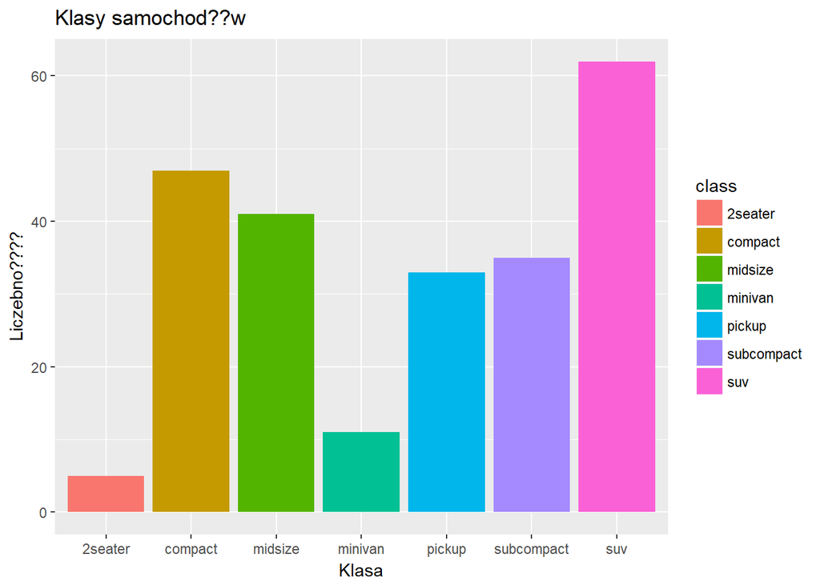